# Risk Factor Analysis

## Outcome Variable

**Outcome Variable:** ever_swasted

## Predictor Variables

**Intervention Variable:** exclfeed3

**Adjustment Set:**

unadjusted

## Stratifying Variables

The analysis was stratified on these variable(s):

- agecat
- studyid
- country

## Data Summary

| agecat | studyid | country | exclfeed3 | ever_swasted | n_cell | n |
| --- | --- | --- | --- | --- | --- | --- |
| 0-24 months (no birth wast) | CMC-V-BCS-2002 | INDIA | 1 | 0 | 6 | 10 |
| 0-24 months (no birth wast) | CMC-V-BCS-2002 | INDIA | 1 | 1 | 4 | 10 |
| 0-24 months (no birth wast) | CMC-V-BCS-2002 | INDIA | 0 | 0 | 0 | 10 |
| 0-24 months (no birth wast) | CMC-V-BCS-2002 | INDIA | 0 | 1 | 0 | 10 |
| 0-24 months (no birth wast) | EE | PAKISTAN | 1 | 0 | 34 | 39 |
| 0-24 months (no birth wast) | EE | PAKISTAN | 1 | 1 | 5 | 39 |
| 0-24 months (no birth wast) | EE | PAKISTAN | 0 | 0 | 0 | 39 |
| 0-24 months (no birth wast) | EE | PAKISTAN | 0 | 1 | 0 | 39 |
| 0-24 months (no birth wast) | GMS-Nepal | NEPAL | 1 | 0 | 283 | 453 |
| 0-24 months (no birth wast) | GMS-Nepal | NEPAL | 1 | 1 | 93 | 453 |
| 0-24 months (no birth wast) | GMS-Nepal | NEPAL | 0 | 0 | 62 | 453 |
| 0-24 months (no birth wast) | GMS-Nepal | NEPAL | 0 | 1 | 15 | 453 |
| 0-24 months (no birth wast) | IRC | INDIA | 1 | 0 | 0 | 10 |
| 0-24 months (no birth wast) | IRC | INDIA | 1 | 1 | 0 | 10 |
| 0-24 months (no birth wast) | IRC | INDIA | 0 | 0 | 6 | 10 |
| 0-24 months (no birth wast) | IRC | INDIA | 0 | 1 | 4 | 10 |
| 0-24 months (no birth wast) | JiVitA-3 | BANGLADESH | 1 | 0 | 12883 | 14768 |
| 0-24 months (no birth wast) | JiVitA-3 | BANGLADESH | 1 | 1 | 478 | 14768 |
| 0-24 months (no birth wast) | JiVitA-3 | BANGLADESH | 0 | 0 | 1350 | 14768 |
| 0-24 months (no birth wast) | JiVitA-3 | BANGLADESH | 0 | 1 | 57 | 14768 |
| 0-24 months (no birth wast) | JiVitA-4 | BANGLADESH | 1 | 0 | 142 | 164 |
| 0-24 months (no birth wast) | JiVitA-4 | BANGLADESH | 1 | 1 | 5 | 164 |
| 0-24 months (no birth wast) | JiVitA-4 | BANGLADESH | 0 | 0 | 16 | 164 |
| 0-24 months (no birth wast) | JiVitA-4 | BANGLADESH | 0 | 1 | 1 | 164 |
| 0-24 months (no birth wast) | Keneba | GAMBIA | 1 | 0 | 1519 | 2015 |
| 0-24 months (no birth wast) | Keneba | GAMBIA | 1 | 1 | 276 | 2015 |
| 0-24 months (no birth wast) | Keneba | GAMBIA | 0 | 0 | 178 | 2015 |
| 0-24 months (no birth wast) | Keneba | GAMBIA | 0 | 1 | 42 | 2015 |
| 0-24 months (no birth wast) | MAL-ED | BANGLADESH | 1 | 0 | 153 | 244 |
| 0-24 months (no birth wast) | MAL-ED | BANGLADESH | 1 | 1 | 6 | 244 |

[output cut: 162 more lines]

The following strata were considered:

- agecat: 0-24 months (no birth wast), studyid: CMC-V-BCS-2002, country: INDIA
- agecat: 0-24 months (no birth wast), studyid: EE, country: PAKISTAN
- agecat: 0-24 months (no birth wast), studyid: GMS-Nepal, country: NEPAL
- agecat: 0-24 months (no birth wast), studyid: IRC, country: INDIA
- agecat: 0-24 months (no birth wast), studyid: JiVitA-3, country: BANGLADESH
- agecat: 0-24 months (no birth wast), studyid: JiVitA-4, country: BANGLADESH
- agecat: 0-24 months (no birth wast), studyid: Keneba, country: GAMBIA
- agecat: 0-24 months (no birth wast), studyid: MAL-ED, country: BANGLADESH
- agecat: 0-24 months (no birth wast), studyid: MAL-ED, country: BRAZIL
- agecat: 0-24 months (no birth wast), studyid: MAL-ED, country: INDIA
- agecat: 0-24 months (no birth wast), studyid: MAL-ED, country: NEPAL
- agecat: 0-24 months (no birth wast), studyid: MAL-ED, country: PERU
- agecat: 0-24 months (no birth wast), studyid: MAL-ED, country: SOUTH AFRICA
- agecat: 0-24 months (no birth wast), studyid: MAL-ED, country: TANZANIA, UNITED REPUBLIC OF
- agecat: 0-24 months (no birth wast), studyid: PROVIDE, country: BANGLADESH
- agecat: 0-24 months (no birth wast), studyid: SAS-CompFeed, country: INDIA
- agecat: 0-6 months (no birth wast), studyid: CMC-V-BCS-2002, country: INDIA
- agecat: 0-6 months (no birth wast), studyid: EE, country: PAKISTAN
- agecat: 0-6 months (no birth wast), studyid: GMS-Nepal, country: NEPAL
- agecat: 0-6 months (no birth wast), studyid: IRC, country: INDIA
- agecat: 0-6 months (no birth wast), studyid: JiVitA-3, country: BANGLADESH
- agecat: 0-6 months (no birth wast), studyid: JiVitA-4, country: BANGLADESH
- agecat: 0-6 months (no birth wast), studyid: Keneba, country: GAMBIA
- agecat: 0-6 months (no birth wast), studyid: MAL-ED, country: BANGLADESH
- agecat: 0-6 months (no birth wast), studyid: MAL-ED, country: BRAZIL
- agecat: 0-6 months (no birth wast), studyid: MAL-ED, country: INDIA
- agecat: 0-6 months (no birth wast), studyid: MAL-ED, country: NEPAL
- agecat: 0-6 months (no birth wast), studyid: MAL-ED, country: PERU
- agecat: 0-6 months (no birth wast), studyid: MAL-ED, country: SOUTH AFRICA
- agecat: 0-6 months (no birth wast), studyid: MAL-ED, country: TANZANIA, UNITED REPUBLIC OF
- agecat: 0-6 months (no birth wast), studyid: PROVIDE, country: BANGLADESH
- agecat: 0-6 months (no birth wast), studyid: SAS-CompFeed, country: INDIA
- agecat: 6-24 months, studyid: CMC-V-BCS-2002, country: INDIA
- agecat: 6-24 months, studyid: EE, country: PAKISTAN
- agecat: 6-24 months, studyid: GMS-Nepal, country: NEPAL
- agecat: 6-24 months, studyid: IRC, country: INDIA
- agecat: 6-24 months, studyid: JiVitA-3, country: BANGLADESH
- agecat: 6-24 months, studyid: JiVitA-4, country: BANGLADESH
- agecat: 6-24 months, studyid: Keneba, country: GAMBIA
- agecat: 6-24 months, studyid: MAL-ED, country: BANGLADESH
- agecat: 6-24 months, studyid: MAL-ED, country: BRAZIL
- agecat: 6-24 months, studyid: MAL-ED, country: INDIA
- agecat: 6-24 months, studyid: MAL-ED, country: NEPAL
- agecat: 6-24 months, studyid: MAL-ED, country: PERU
- agecat: 6-24 months, studyid: MAL-ED, country: SOUTH AFRICA
- agecat: 6-24 months, studyid: MAL-ED, country: TANZANIA, UNITED REPUBLIC OF
- agecat: 6-24 months, studyid: PROVIDE, country: BANGLADESH
- agecat: 6-24 months, studyid: SAS-CompFeed, country: INDIA

### Dropped Strata

Some strata were dropped due to rare outcomes:

- agecat: 0-24 months (no birth wast), studyid: CMC-V-BCS-2002, country: INDIA
- agecat: 0-24 months (no birth wast), studyid: EE, country: PAKISTAN
- agecat: 0-24 months (no birth wast), studyid: IRC, country: INDIA
- agecat: 0-24 months (no birth wast), studyid: JiVitA-4, country: BANGLADESH
- agecat: 0-24 months (no birth wast), studyid: MAL-ED, country: BRAZIL
- agecat: 0-24 months (no birth wast), studyid: MAL-ED, country: NEPAL
- agecat: 0-24 months (no birth wast), studyid: MAL-ED, country: PERU
- agecat: 0-24 months (no birth wast), studyid: MAL-ED, country: SOUTH AFRICA
- agecat: 0-24 months (no birth wast), studyid: MAL-ED, country: TANZANIA, UNITED REPUBLIC OF
- agecat: 0-24 months (no birth wast), studyid: SAS-CompFeed, country: INDIA
- agecat: 0-6 months (no birth wast), studyid: CMC-V-BCS-2002, country: INDIA
- agecat: 0-6 months (no birth wast), studyid: EE, country: PAKISTAN
- agecat: 0-6 months (no birth wast), studyid: IRC, country: INDIA
- agecat: 0-6 months (no birth wast), studyid: JiVitA-4, country: BANGLADESH
- agecat: 0-6 months (no birth wast), studyid: MAL-ED, country: BANGLADESH
- agecat: 0-6 months (no birth wast), studyid: MAL-ED, country: BRAZIL
- agecat: 0-6 months (no birth wast), studyid: MAL-ED, country: INDIA
- agecat: 0-6 months (no birth wast), studyid: MAL-ED, country: NEPAL
- agecat: 0-6 months (no birth wast), studyid: MAL-ED, country: PERU
- agecat: 0-6 months (no birth wast), studyid: MAL-ED, country: SOUTH AFRICA
- agecat: 0-6 months (no birth wast), studyid: MAL-ED, country: TANZANIA, UNITED REPUBLIC OF
- agecat: 0-6 months (no birth wast), studyid: PROVIDE, country: BANGLADESH
- agecat: 0-6 months (no birth wast), studyid: SAS-CompFeed, country: INDIA
- agecat: 6-24 months, studyid: CMC-V-BCS-2002, country: INDIA
- agecat: 6-24 months, studyid: EE, country: PAKISTAN
- agecat: 6-24 months, studyid: IRC, country: INDIA
- agecat: 6-24 months, studyid: JiVitA-4, country: BANGLADESH
- agecat: 6-24 months, studyid: MAL-ED, country: BANGLADESH
- agecat: 6-24 months, studyid: MAL-ED, country: BRAZIL
- agecat: 6-24 months, studyid: MAL-ED, country: INDIA
- agecat: 6-24 months, studyid: MAL-ED, country: NEPAL
- agecat: 6-24 months, studyid: MAL-ED, country: PERU
- agecat: 6-24 months, studyid: MAL-ED, country: SOUTH AFRICA
- agecat: 6-24 months, studyid: MAL-ED, country: TANZANIA, UNITED REPUBLIC OF
- agecat: 6-24 months, studyid: PROVIDE, country: BANGLADESH
- agecat: 6-24 months, studyid: SAS-CompFeed, country: INDIA

## Methods Detail

We’re interested in the causal parameters $E[Y_a]$ for all values of $a \in \mathcal{A}$. These parameters represent the mean outcome if, possibly contrary to fact, we intervened to set all units to have $A=a$. Under the randomization and positivity assumptions, these are identified by the statistical parameters $\psi_a=E_W[E_{Y|A,W}(Y|A=a,W)]$. In addition, we’re interested in the mean of $Y$, $E[Y]$ under no intervention (the observed mean). We will estimate these parameters by using SuperLearner to fit the relevant likelihood factors – $E_{Y|A,W}(Y|A=a,W)$ and $p(A=a|W)$, and then updating our likelihood fit using a joint TMLE.

For unadjusted analyses ($W=\{\}$), initial likelihoods were estimated using Lrnr_glm to estimate the simple $E(Y|A)$ and Lrnr_mean to estimate $p(A)$. For adjusted analyses, a small library containing Lrnr_glmnet, Lrnr_xgboost, and Lrnr_mean was used.

Having estimated these parameters, we will then use the delta method to estimate relative risks and attributable risks relative to a prespecified baseline level of $A$.

# Results Detail

## Results Plots

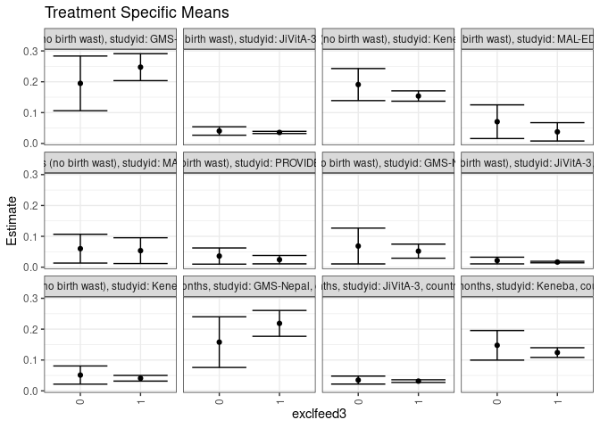

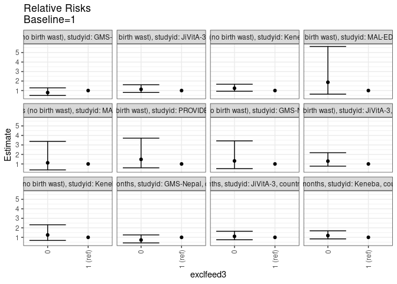

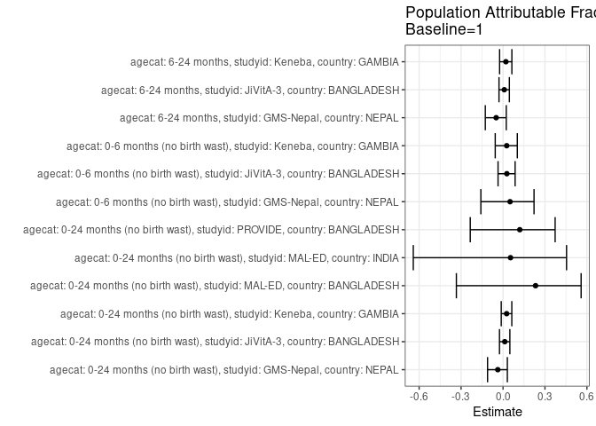

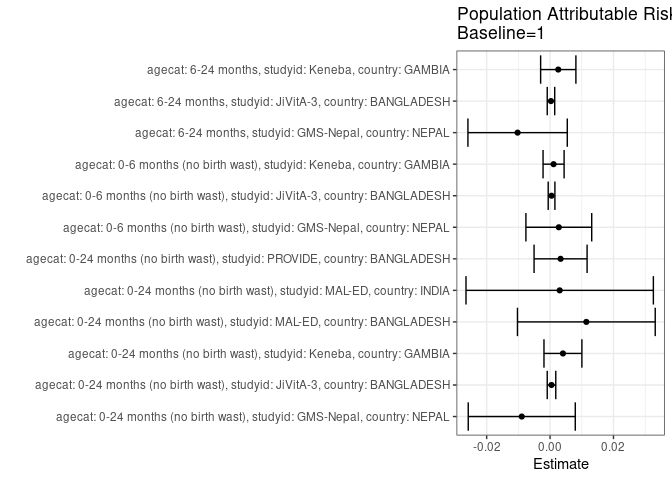

## Results Table

### Parameter: TSM

| agecat | studyid | country | intervention_level | baseline_level | estimate | ci_lower | ci_upper |
| --- | --- | --- | --- | --- | --- | --- | --- |
| 0-24 months (no birth wast) | GMS-Nepal | NEPAL | 1 | NA | 0.2473404 | 0.2036807 | 0.2910001 |
| 0-24 months (no birth wast) | GMS-Nepal | NEPAL | 0 | NA | 0.1948052 | 0.1062461 | 0.2833643 |
| 0-24 months (no birth wast) | JiVitA-3 | BANGLADESH | 1 | NA | 0.0357758 | 0.0322514 | 0.0393001 |
| 0-24 months (no birth wast) | JiVitA-3 | BANGLADESH | 0 | NA | 0.0405117 | 0.0268619 | 0.0541616 |
| 0-24 months (no birth wast) | Keneba | GAMBIA | 1 | NA | 0.1537604 | 0.1370691 | 0.1704518 |
| 0-24 months (no birth wast) | Keneba | GAMBIA | 0 | NA | 0.1909091 | 0.1389626 | 0.2428556 |
| 0-24 months (no birth wast) | MAL-ED | BANGLADESH | 1 | NA | 0.0377358 | 0.0080557 | 0.0674160 |
| 0-24 months (no birth wast) | MAL-ED | BANGLADESH | 0 | NA | 0.0705882 | 0.0160249 | 0.1251515 |
| 0-24 months (no birth wast) | MAL-ED | INDIA | 1 | NA | 0.0535714 | 0.0117714 | 0.0953714 |
| 0-24 months (no birth wast) | MAL-ED | INDIA | 0 | NA | 0.0600000 | 0.0133433 | 0.1066567 |
| 0-24 months (no birth wast) | PROVIDE | BANGLADESH | 1 | NA | 0.0243408 | 0.0107277 | 0.0379539 |
| 0-24 months (no birth wast) | PROVIDE | BANGLADESH | 0 | NA | 0.0360825 | 0.0098202 | 0.0623447 |
| 0-6 months (no birth wast) | GMS-Nepal | NEPAL | 1 | NA | 0.0519126 | 0.0291583 | 0.0746669 |
| 0-6 months (no birth wast) | GMS-Nepal | NEPAL | 0 | NA | 0.0684932 | 0.0104837 | 0.1265026 |
| 0-6 months (no birth wast) | JiVitA-3 | BANGLADESH | 1 | NA | 0.0166063 | 0.0141131 | 0.0190995 |
| 0-6 months (no birth wast) | JiVitA-3 | BANGLADESH | 0 | NA | 0.0215054 | 0.0105848 | 0.0324259 |
| 0-6 months (no birth wast) | Keneba | GAMBIA | 1 | NA | 0.0408735 | 0.0316886 | 0.0500584 |
| 0-6 months (no birth wast) | Keneba | GAMBIA | 0 | NA | 0.0511628 | 0.0217043 | 0.0806213 |
| 6-24 months | GMS-Nepal | NEPAL | 1 | NA | 0.2186667 | 0.1767850 | 0.2605483 |
| 6-24 months | GMS-Nepal | NEPAL | 0 | NA | 0.1578947 | 0.0758236 | 0.2399659 |
| 6-24 months | JiVitA-3 | BANGLADESH | 1 | NA | 0.0316340 | 0.0273325 | 0.0359356 |
| 6-24 months | JiVitA-3 | BANGLADESH | 0 | NA | 0.0349398 | 0.0220618 | 0.0478177 |
| 6-24 months | Keneba | GAMBIA | 1 | NA | 0.1241176 | 0.1084401 | 0.1397952 |
| 6-24 months | Keneba | GAMBIA | 0 | NA | 0.1476190 | 0.0996302 | 0.1956079 |

### Parameter: E(Y)

| agecat | studyid | country | intervention_level | baseline_level | estimate | ci_lower | ci_upper |
| --- | --- | --- | --- | --- | --- | --- | --- |
| 0-24 months (no birth wast) | GMS-Nepal | NEPAL | NA | NA | 0.2384106 | 0.1991278 | 0.2776934 |
| 0-24 months (no birth wast) | JiVitA-3 | BANGLADESH | NA | NA | 0.0362270 | 0.0327939 | 0.0396601 |
| 0-24 months (no birth wast) | Keneba | GAMBIA | NA | NA | 0.1578164 | 0.1418944 | 0.1737384 |
| 0-24 months (no birth wast) | MAL-ED | BANGLADESH | NA | NA | 0.0491803 | 0.0219915 | 0.0763691 |
| 0-24 months (no birth wast) | MAL-ED | INDIA | NA | NA | 0.0566038 | 0.0254237 | 0.0877838 |
| 0-24 months (no birth wast) | PROVIDE | BANGLADESH | NA | NA | 0.0276565 | 0.0153851 | 0.0399279 |
| 0-6 months (no birth wast) | GMS-Nepal | NEPAL | NA | NA | 0.0546697 | 0.0333797 | 0.0759597 |
| 0-6 months (no birth wast) | JiVitA-3 | BANGLADESH | NA | NA | 0.0170730 | 0.0145369 | 0.0196091 |
| 0-6 months (no birth wast) | Keneba | GAMBIA | NA | NA | 0.0419790 | 0.0331901 | 0.0507680 |
| 6-24 months | GMS-Nepal | NEPAL | NA | NA | 0.2084257 | 0.1708970 | 0.2459544 |
| 6-24 months | JiVitA-3 | BANGLADESH | NA | NA | 0.0319193 | 0.0278547 | 0.0359839 |
| 6-24 months | Keneba | GAMBIA | NA | NA | 0.1267016 | 0.1117799 | 0.1416232 |

### Parameter: RR

| agecat | studyid | country | intervention_level | baseline_level | estimate | ci_lower | ci_upper |
| --- | --- | --- | --- | --- | --- | --- | --- |
| 0-24 months (no birth wast) | GMS-Nepal | NEPAL | 1 | 1 | 1.0000000 | 1.0000000 | 1.000000 |
| 0-24 months (no birth wast) | GMS-Nepal | NEPAL | 0 | 1 | 0.7875995 | 0.4836295 | 1.282620 |
| 0-24 months (no birth wast) | JiVitA-3 | BANGLADESH | 1 | 1 | 1.0000000 | 1.0000000 | 1.000000 |
| 0-24 months (no birth wast) | JiVitA-3 | BANGLADESH | 0 | 1 | 1.1323790 | 0.7965022 | 1.609892 |
| 0-24 months (no birth wast) | Keneba | GAMBIA | 1 | 1 | 1.0000000 | 1.0000000 | 1.000000 |
| 0-24 months (no birth wast) | Keneba | GAMBIA | 0 | 1 | 1.2416008 | 0.9263028 | 1.664221 |
| 0-24 months (no birth wast) | MAL-ED | BANGLADESH | 1 | 1 | 1.0000000 | 1.0000000 | 1.000000 |
| 0-24 months (no birth wast) | MAL-ED | BANGLADESH | 0 | 1 | 1.8705882 | 0.6209381 | 5.635184 |
| 0-24 months (no birth wast) | MAL-ED | INDIA | 1 | 1 | 1.0000000 | 1.0000000 | 1.000000 |
| 0-24 months (no birth wast) | MAL-ED | INDIA | 0 | 1 | 1.1200000 | 0.3722239 | 3.370015 |
| 0-24 months (no birth wast) | PROVIDE | BANGLADESH | 1 | 1 | 1.0000000 | 1.0000000 | 1.000000 |
| 0-24 months (no birth wast) | PROVIDE | BANGLADESH | 0 | 1 | 1.4823883 | 0.5920038 | 3.711927 |
| 0-6 months (no birth wast) | GMS-Nepal | NEPAL | 1 | 1 | 1.0000000 | 1.0000000 | 1.000000 |
| 0-6 months (no birth wast) | GMS-Nepal | NEPAL | 0 | 1 | 1.3193944 | 0.5084106 | 3.424007 |
| 0-6 months (no birth wast) | JiVitA-3 | BANGLADESH | 1 | 1 | 1.0000000 | 1.0000000 | 1.000000 |
| 0-6 months (no birth wast) | JiVitA-3 | BANGLADESH | 0 | 1 | 1.2950147 | 0.7686657 | 2.181785 |
| 0-6 months (no birth wast) | Keneba | GAMBIA | 1 | 1 | 1.0000000 | 1.0000000 | 1.000000 |
| 0-6 months (no birth wast) | Keneba | GAMBIA | 0 | 1 | 1.2517362 | 0.6746607 | 2.322417 |
| 6-24 months | GMS-Nepal | NEPAL | 1 | 1 | 1.0000000 | 1.0000000 | 1.000000 |
| 6-24 months | GMS-Nepal | NEPAL | 0 | 1 | 0.7220796 | 0.4149617 | 1.256499 |
| 6-24 months | JiVitA-3 | BANGLADESH | 1 | 1 | 1.0000000 | 1.0000000 | 1.000000 |
| 6-24 months | JiVitA-3 | BANGLADESH | 0 | 1 | 1.1044986 | 0.7440992 | 1.639455 |
| 6-24 months | Keneba | GAMBIA | 1 | 1 | 1.0000000 | 1.0000000 | 1.000000 |
| 6-24 months | Keneba | GAMBIA | 0 | 1 | 1.1893478 | 0.8391570 | 1.685678 |

### Parameter: PAR

| agecat | studyid | country | intervention_level | baseline_level | estimate | ci_lower | ci_upper |
| --- | --- | --- | --- | --- | --- | --- | --- |
| 0-24 months (no birth wast) | GMS-Nepal | NEPAL | 1 | NA | -0.0089298 | -0.0258112 | 0.0079515 |
| 0-24 months (no birth wast) | JiVitA-3 | BANGLADESH | 1 | NA | 0.0004512 | -0.0008958 | 0.0017983 |
| 0-24 months (no birth wast) | Keneba | GAMBIA | 1 | NA | 0.0040559 | -0.0019227 | 0.0100346 |
| 0-24 months (no birth wast) | MAL-ED | BANGLADESH | 1 | NA | 0.0114445 | -0.0102827 | 0.0331716 |
| 0-24 months (no birth wast) | MAL-ED | INDIA | 1 | NA | 0.0030323 | -0.0265192 | 0.0325839 |
| 0-24 months (no birth wast) | PROVIDE | BANGLADESH | 1 | NA | 0.0033157 | -0.0050469 | 0.0116783 |
| 0-6 months (no birth wast) | GMS-Nepal | NEPAL | 1 | NA | 0.0027571 | -0.0076207 | 0.0131350 |
| 0-6 months (no birth wast) | JiVitA-3 | BANGLADESH | 1 | NA | 0.0004667 | -0.0005894 | 0.0015229 |
| 0-6 months (no birth wast) | Keneba | GAMBIA | 1 | NA | 0.0011056 | -0.0022129 | 0.0044240 |
| 6-24 months | GMS-Nepal | NEPAL | 1 | NA | -0.0102409 | -0.0259094 | 0.0054275 |
| 6-24 months | JiVitA-3 | BANGLADESH | 1 | NA | 0.0002853 | -0.0008934 | 0.0014640 |
| 6-24 months | Keneba | GAMBIA | 1 | NA | 0.0025839 | -0.0029765 | 0.0081444 |

### Parameter: PAF

| agecat | studyid | country | intervention_level | baseline_level | estimate | ci_lower | ci_upper |
| --- | --- | --- | --- | --- | --- | --- | --- |
| 0-24 months (no birth wast) | GMS-Nepal | NEPAL | 1 | NA | -0.0374557 | -0.1106348 | 0.0309017 |
| 0-24 months (no birth wast) | JiVitA-3 | BANGLADESH | 1 | NA | 0.0124551 | -0.0253006 | 0.0488206 |
| 0-24 months (no birth wast) | Keneba | GAMBIA | 1 | NA | 0.0257003 | -0.0128706 | 0.0628025 |
| 0-24 months (no birth wast) | MAL-ED | BANGLADESH | 1 | NA | 0.2327044 | -0.3336978 | 0.5585638 |
| 0-24 months (no birth wast) | MAL-ED | INDIA | 1 | NA | 0.0535714 | -0.6417907 | 0.4544207 |
| 0-24 months (no birth wast) | PROVIDE | BANGLADESH | 1 | NA | 0.1198890 | -0.2346253 | 0.3726069 |
| 0-6 months (no birth wast) | GMS-Nepal | NEPAL | 1 | NA | 0.0504326 | -0.1585940 | 0.2217479 |
| 0-6 months (no birth wast) | JiVitA-3 | BANGLADESH | 1 | NA | 0.0273370 | -0.0355949 | 0.0864445 |
| 0-6 months (no birth wast) | Keneba | GAMBIA | 1 | NA | 0.0263358 | -0.0558205 | 0.1020993 |
| 6-24 months | GMS-Nepal | NEPAL | 1 | NA | -0.0491348 | -0.1268184 | 0.0231933 |
| 6-24 months | JiVitA-3 | BANGLADESH | 1 | NA | 0.0089373 | -0.0287775 | 0.0452694 |
| 6-24 months | Keneba | GAMBIA | 1 | NA | 0.0203938 | -0.0244413 | 0.0632666 |